# Spooky Author Identification - simple EDA

# Prepare word clouds for each author

At the begining - two functions for plots:

```r
# word cloud
AuthorWordCloud <- function(author_id) {
   train_words_author %>%
      filter(author == author_id) %>%
      with(wordcloud(word, n, max.words = 200,
                     scale = c(1.8, 0.5),
                     colors = RColorBrewer::brewer.pal(9, "YlOrRd")[3:9]))
}

# bar plot
AuthorWordBars <- function(author_id) {
   train_words_author %>%
      filter(author == author_id) %>%
      top_n(50, n) %>%
      arrange(n) %>%
      mutate(word = factor(word, levels = word)) %>%
      ggplot() +
         geom_col(aes(word, n), color = "gray80", fill = "lightgreen") +
         coord_flip() +
         labs(title = paste0("Most frequent words used by ", author_id))
}
```

## Word cloud for EAP:

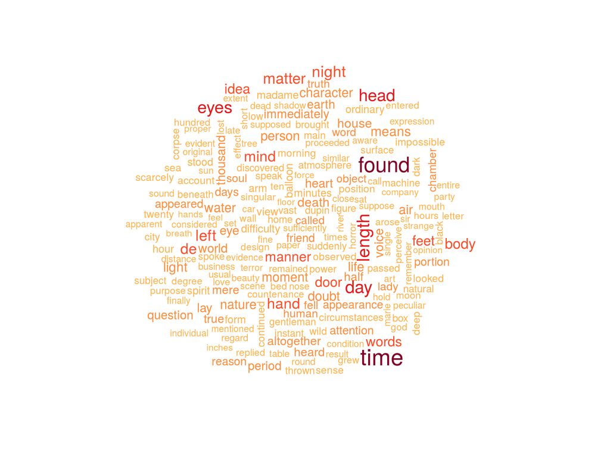

```r
AuthorWordCloud("EAP")
```

## Barplot for EAP:

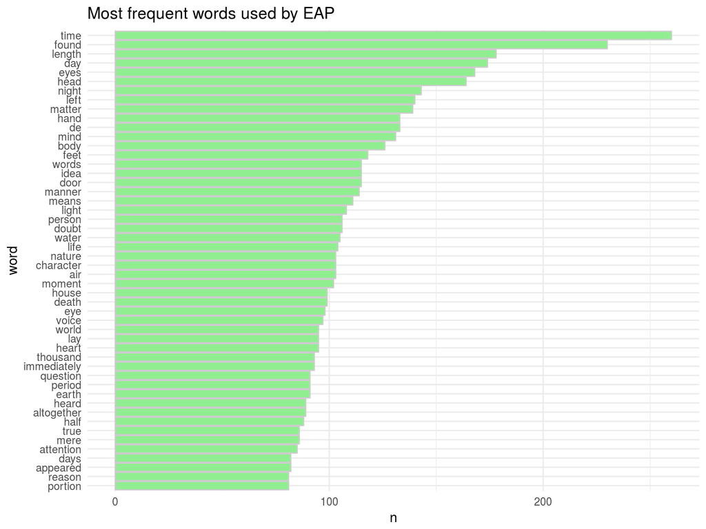

```r
AuthorWordBars("EAP")
```

## Word cloud for HPL:

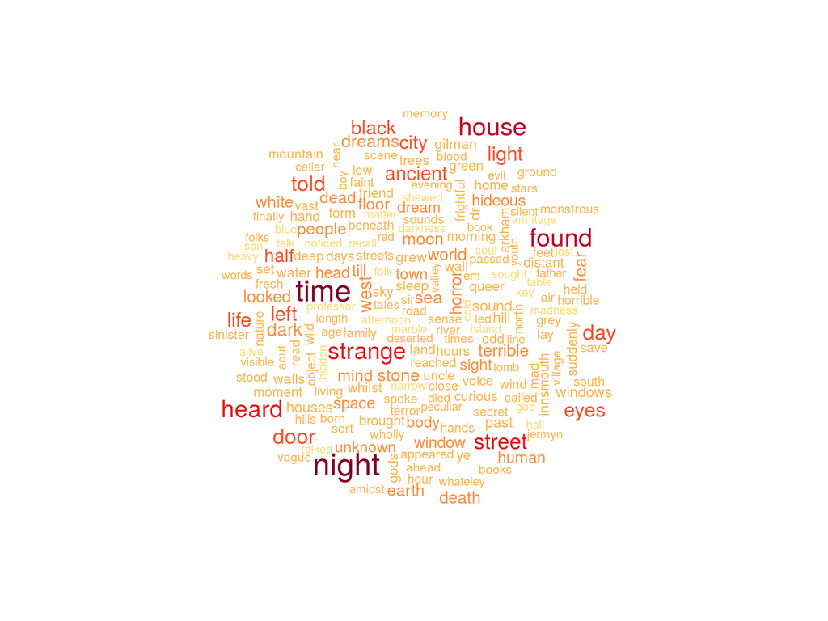

```r
AuthorWordCloud("HPL")
```

## Barplot for HPL:

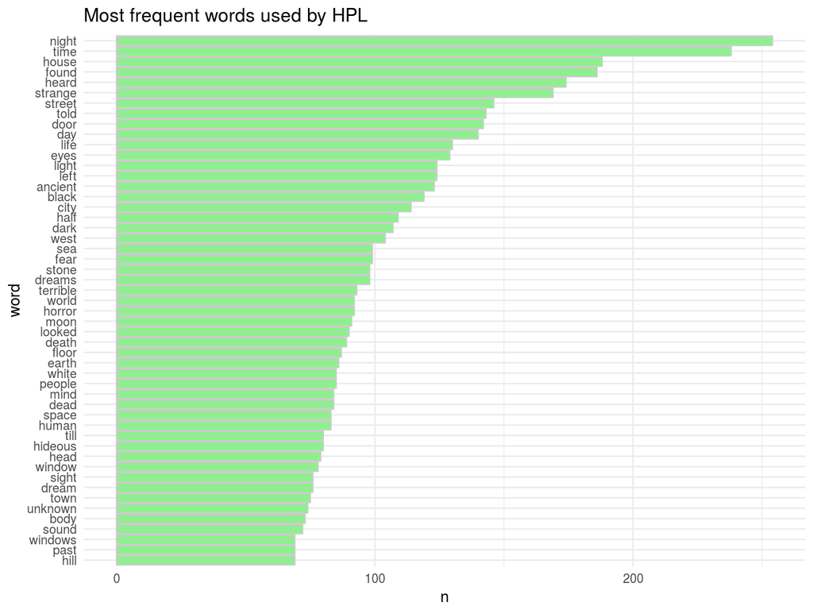

```r
AuthorWordBars("HPL")
```

## Word cloud for MWS:

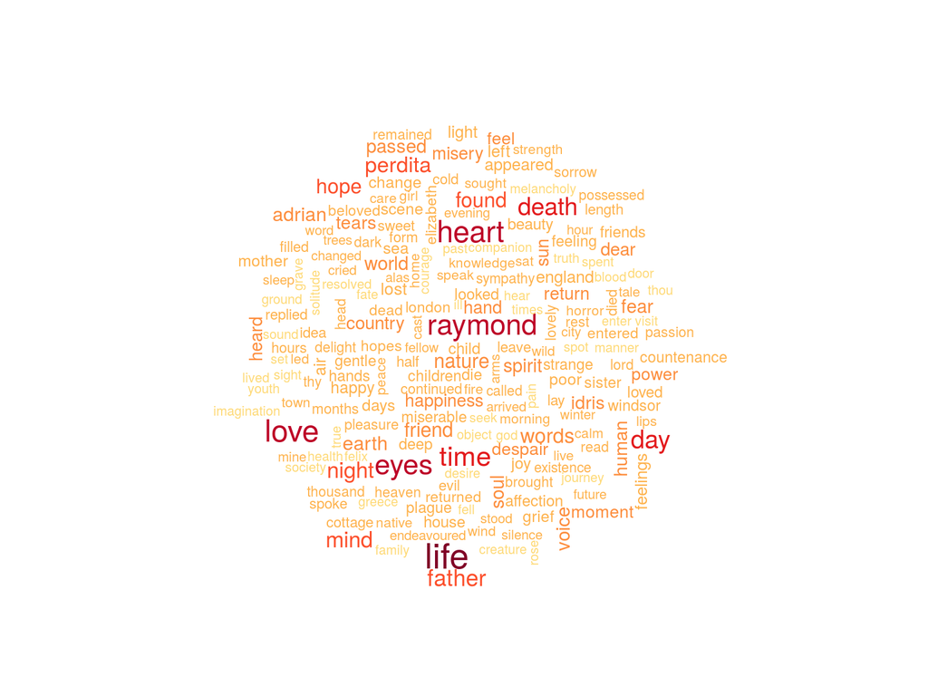

```r
AuthorWordCloud("MWS")
```

## Barplot for MWS:

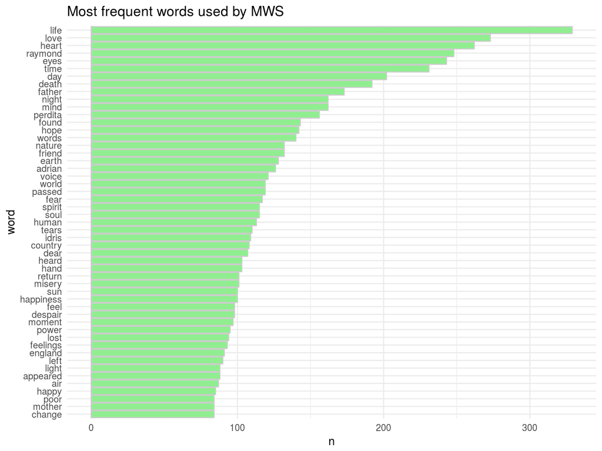

```r
AuthorWordBars("MWS")
```

Top 20 words and how often authors used them?

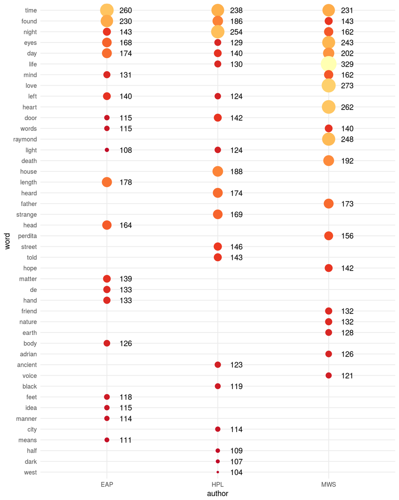

```r
train_words_author %>%
   group_by(author) %>%
   top_n(20, n) %>%
   ungroup() %>%
   group_by(word) %>%
   mutate(tot_n = sum(n)) %>%
   ungroup() %>%
   arrange(desc(tot_n)) %>%
   mutate(word = factor(word, levels = rev(unique(word)))) %>%
   ggplot() +
   geom_point(aes(author, word, size = n, color = n), show.legend = FALSE) +
   geom_text(aes(author, word, label = n), hjust = -1) +
   scale_color_distiller(palette = "YlOrRd") +
   scale_size_continuous(range = c(1, 10))
```

Who uses which word?

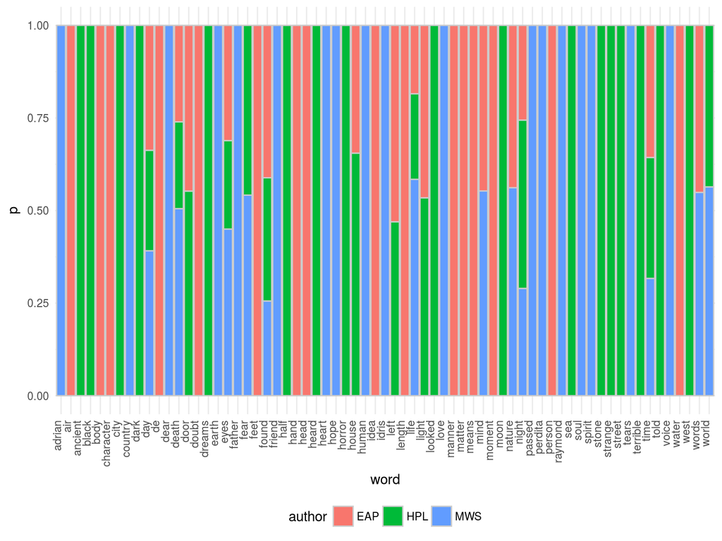

```r
train_words_author %>%
   group_by(author) %>%
   top_n(30, n) %>%
   ungroup() %>%
   group_by(word) %>%
   mutate(p = n/sum(n)) %>%
   ungroup() %>%
   ggplot() +
      geom_col(aes(word, p, fill = author), color = "gray80") +
      theme(axis.text.x = element_text(angle = 90, vjust = 0, hjust = 1),
            legend.position = "bottom")
```

**Similarity of authors:**

[figure not shown]

```r
words_prob <- train_words_author %>%
   spread(author, n, fill = 0) %>%
   na.omit()

words_prob2 <- train_words_author %>%
   spread(word, n, fill = 0) %>%
   na.omit()

corrgram(words_prob, lower.panel = panel.shade, upper.panel = panel.cor)
```

Does it mean anything? I don’t know yet :)

**Similarity of words** (20 most popular of them):

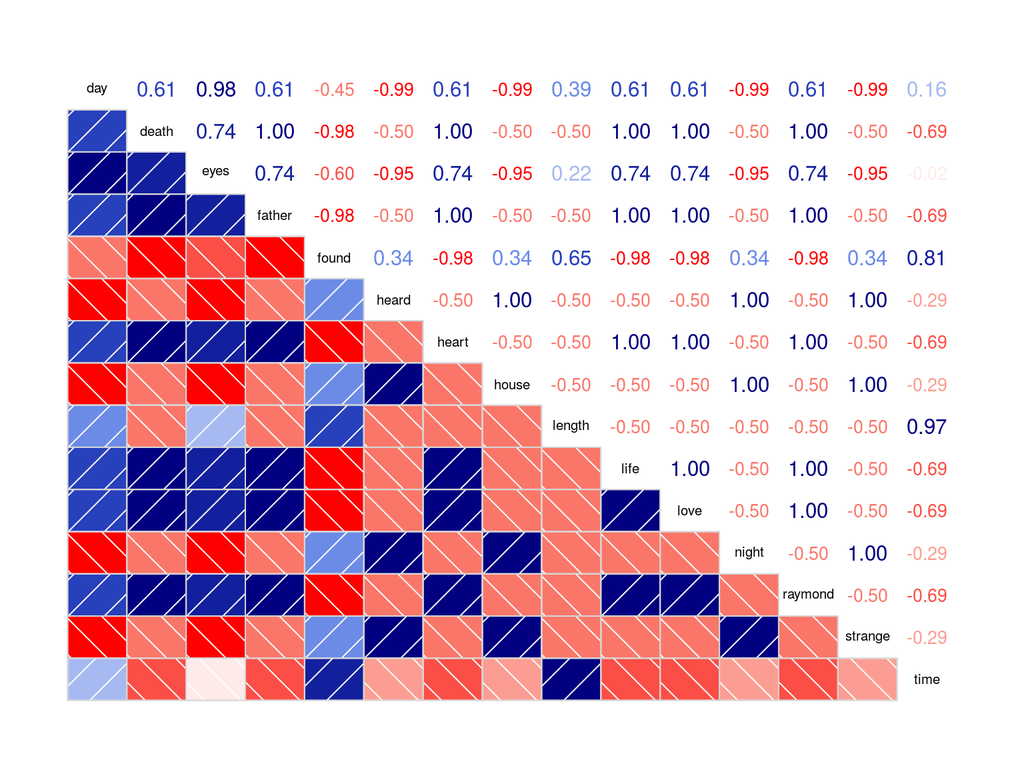

```r
words_prob2 <- train_words_author %>%
   top_n(20, n) %>%
   spread(word, n, fill = 0) %>%
   na.omit()

corrgram(words_prob2, lower.panel = panel.shade, upper.panel = panel.cor)
```

```r
rm(train_words_author, words_prob, words_prob2) # won't be needed
```

Does it mean anything? I don’t think so, but it look interesting :)

# Document Term Matrix

```r
train_dtm <- train %>%
   unnest_tokens(word, text) %>%
   count(author, id, word) %>%
   ungroup() %>%
   cast_dtm(id, word, n)

train_dtm
```

```
## <<DocumentTermMatrix (documents: 19579, terms: 25616)>>
## Non-/sparse entries: 444771/501090893
## Sparsity           : 100%
## Maximal term length: 19
## Weighting          : term frequency (tf)
```

We have big matrix with 19579 documents (as rows) and 25616 words (as columns).

For a while we can make it smaller by removing about 99% of columns (those sparse ones):

```r
train_dtm_small <- removeSparseTerms(train_dtm, 0.99)
train_dtm_small
```

```
## <<DocumentTermMatrix (documents: 19579, terms: 245)>>
## Non-/sparse entries: 242815/4554040
## Sparsity           : 95%
## Maximal term length: 9
## Weighting          : term frequency (tf)
```

With this smaller matrix we can do

# PCA for DTM

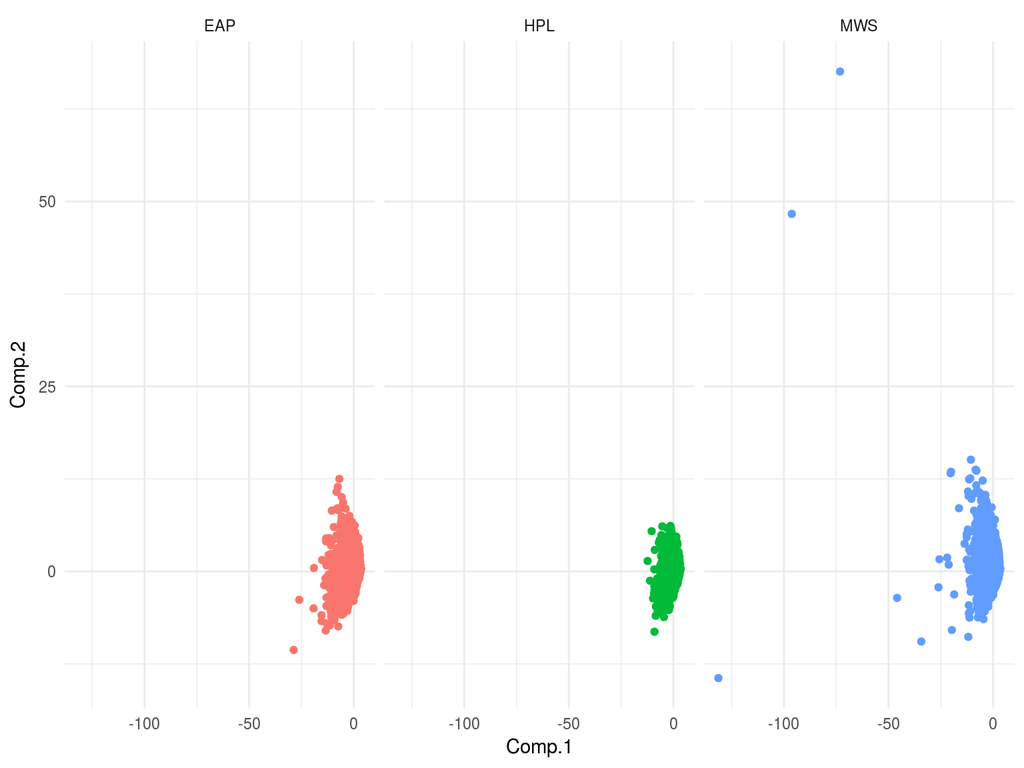

```r
train_dtm_small_mat <- as.matrix(train_dtm_small)

pca <- princomp(train_dtm_small_mat, cor = TRUE)

pca_scores <- pca$scores %>%
   as.data.frame() %>%
   rownames_to_column("id") %>%
   left_join(train %>% select(id, author_name = author), by = "id")

pca_scores %>%
   ggplot() +
   geom_point(aes(Comp.1, Comp.2, color = author_name), show.legend = FALSE) +
   facet_wrap(~author_name)
```

```r
rm(pca, pca_scores) # remove them
```

So PCA seems to be useless…

Mayby k-means then?

# K-means fot DTM

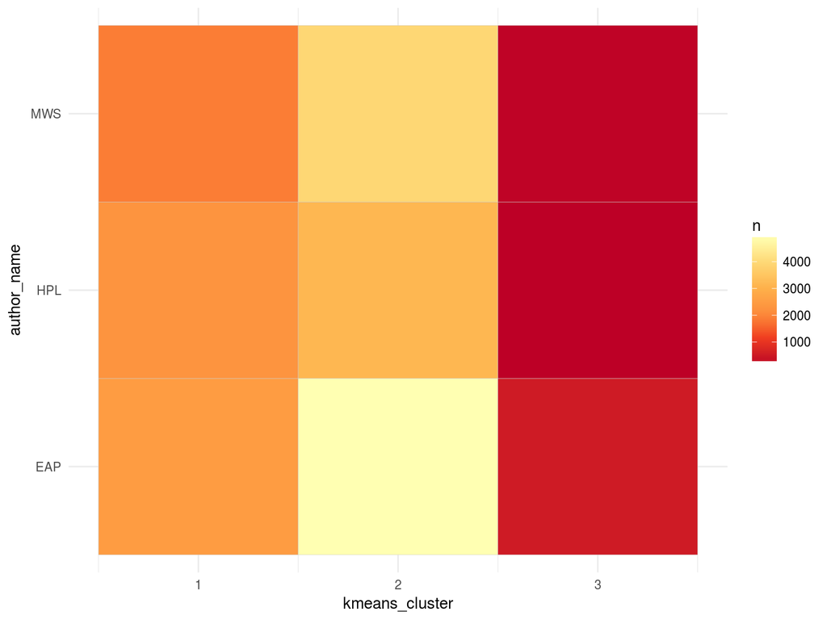

```r
train_dtm_small_df <- train_dtm_small_mat %>%
   as.data.frame() %>%
   rownames_to_column("id") %>%
   left_join(train %>% select(id, author_name = author), by = "id")

rm(train_dtm_small_mat) # save some memory :)


train_dtm_small_df$kmeans_cluster <- kmeans(train_dtm_small_df %>% select(-id, -author_name), 3)$cluster

train_dtm_small_df %>%
   count(kmeans_cluster, author_name) %>%
   ungroup() %>%
   ggplot() +
   geom_tile(aes(kmeans_cluster, author_name, fill = n), color = "gray80") +
   scale_fill_distiller(palette = "YlOrRd")
```

Is also looks useless.

# Decission Trees for DTM

```r
# for tests
train_dtm_small_rf <- train_dtm_small_df %>%
  select(-id, -kmeans_cluster) %>%
  mutate(author_name = factor(author_name))

# for competiton
# needs a lot of memory!
# train_dtm_small_rf <- as.matrix(train_dtm) %>%
#    as.data.frame() %>%
#    rownames_to_column("id") %>%
#    left_join(train %>% select(id, author_name = author), by = "id") %>%
#    select(-id) %>%
#    mutate(author_name = factor(author_name))

# need to change columnames
colnames(train_dtm_small_rf) <- paste0(colnames(train_dtm_small_rf), "_word")
train_dtm_small_rf <- rename(train_dtm_small_rf, author_name = author_name_word)


model_rf <- randomForest(author_name ~ .,
                         # do not use sample_frac in competition!
                         train_dtm_small_rf %>% sample_frac(0.2),
                         # train_dtm_small_rf,
                         ntree = 50,
                         mtry = 6,
                         proximity = TRUE,
                         importance = TRUE)
```

Look at confusion matrix:

```r
model_rf$confusion
```

```
##      EAP HPL MWS class.error
## EAP 1158 218 211   0.2703214
## HPL  456 516 152   0.5409253
## MWS  427 179 599   0.5029046
```

Variables importance:

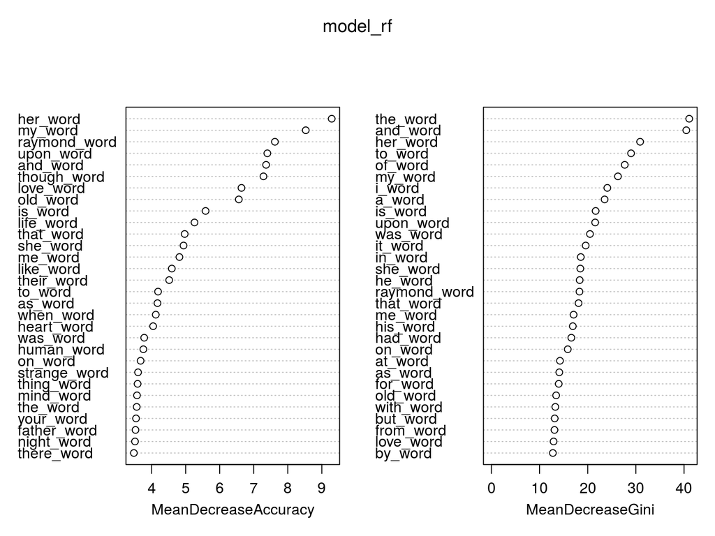

```r
varImpPlot(model_rf)
```

Mostly stop words - it doesn’t dobe well…

But we need to check this. Fisrt prepare test data:

```r
words_in_train <- train_dtm_small$dimnames$Terms

test_dtm_df <- test %>%
   unnest_tokens(word, text) %>%
   count(id, word) %>%
   ungroup() %>%
   filter(word %in% words_in_train) %>%
   mutate(word = paste0(word, "_word")) %>%
   cast_dtm(id, word, n) %>%
   as.matrix() %>%
   as.data.frame() %>%
   rownames_to_column("id")
```

Predict:

```r
test_pred_rf <- predict(model_rf, newdata = test_dtm_df, type = "prob")

test_pred_rf <- cbind(test_dtm_df["id"], test_pred_rf)
```

Do we have all IDs from test dataset in our predictions?

```r
nrow(test_pred_rf) == nrow(test)
```

```
## [1] FALSE
```

No, something is missing :( What is it:

```r
filter(test, !id %in% test_pred_rf$id)
```

```
##        id
## 1 id11200
## 2 id23727
## 3 id12998
## 4 id07861
## 5 id22879
## 6 id23301
## 7 id00729
## 8 id03389
##                                                                                                                                         text
## 1                                                                                                                   Understand, eh?"" UNCLE.
## 2                                                                                                           Coleridge's ""Ancient Mariner.""
## 3                                                                                                           birth, wealth, talent, goodness?
## 4                                                                                                  Met Gruff shortly afterward, blind drunk.
## 5                                                                                                              Evening Paper Tuesday, June .
## 6 Cada piedra un piramide levanta, y cada flor costruye un monumento, cada edificio es un sepulcro altivo, cada soldado un esqueleto vivo.""
## 7                                                                                                                 Nobody'll believe nothin'.
## 8                                                                                                                     Txld yxu sx, yxu knxw.
```

So let’s add dummy variables for missing IDs:

```r
dummy <- test %>%
   filter(!id %in% test_pred_rf$id) %>%
   select(id) %>%
   mutate(EAP = 1/3,
          HPL = 1/3,
          MWS = 1/3)

test_pred_rf_submit <- bind_rows(test_pred_rf, dummy)
```

Check once more time:

```r
nrow(test_pred_rf_submit) == nrow(test)
```

```
## [1] TRUE
```

```r
filter(test, !id %in% test_pred_rf_submit$id)
```

```
## [1] id   text
## <0 rows> (or 0-length row.names)
```

Same number of rows, no missing ID - we can submit our prediction!

```r
fwrite(test_pred_rf_submit, file = "RandomForest_submit.csv")
```

# XGBoost for DTM

TBC

# Keras for DTM

TBC